# testVBZ

```r
library(tidyverse)
library(lubridate)
```

```r
#########################################################################################
################### Delay Increments Along Route Segments and At Stops  #################
#########################################################################################
# This function will return a tibble (tidyverse dataframe) of the delays greater than
# a certain integer, measured in minutes.  Minute values are rounded down from seconds.
#  PARAMETERS:
# small_tib -- a fahrzeitensollist .csv dataset from VBZ
# out_tib -- the name of an empty tibble
# work.line -- the bus or tram line of interest
# min_delay_seg_min -- the minimum delay time for delays on route segments, in minutes
# min_delay_von_min -- the minimum delay time for delays at the von stop
#
# Requires: tidyverse or dplyr library
#
# Contributers:  Peter B. Pearman  pbpearman@gmail.com
#
##########################################################################################
# small_tib  --a VBZ delay dataset
# out_tib    --the output dataset
# work.line  --the tram or bus line in question
# min_delay_seg_min --the threshold increment of additional delay on a segment
# min_delay_von_min --the threshold increment of additional delay at the 'von' stop
delays <- function(small_tib,out_tib,work.line,min_delay_seg_min,min_delay_von_min){
  small_tib$halt_kurz_nach1 <- as.character(small_tib$halt_kurz_nach1)
  small_tib$halt_kurz_von1 <- as.character(small_tib$halt_kurz_von1)
  delay2 <- small_tib %>%
    select(linie,richtung,betriebsdatum,fahrzeug,umlauf_von,halt_id_nach,halt_id_von,datum_von,soll_ab_von,ist_ab_von,soll_an_nach,ist_an_nach1,
         soll_an_von,ist_an_von,halt_punkt_id_von,halt_punkt_id_nach,halt_kurz_von1,halt_kurz_nach1,halt_punkt_diva_von,halt_punkt_diva_nach) %>%
    filter(linie == work.line) %>%

         #delays during segments of the line

    mutate(soll_seg = soll_an_nach - soll_ab_von,
         ist_seg = ist_an_nach1 - ist_ab_von,
         delay_seg = soll_seg - ist_seg,
         # delay at the station
         soll_at_von = soll_ab_von - soll_an_von,
         ist_at_von = ist_ab_von - ist_an_von,
         delay_von = ist_at_von - soll_at_von)

        # now filter out lines that do not have at least one delay that is greater than the necessary minimum
  delay3 <- delay2 %>%
    mutate(delay_seg_min = floor(delay_seg/60), delay_von_min = floor(delay_von/60)) %>%
    filter(delay_seg_min >= min_delay_seg_min | delay_von_min >= min_delay_von_min)

  out_tib <- bind_rows(delay3,out_tib)
  return(out_tib)
}
```

```r
out_tib <- tibble()
temp=list.files('../data/fahrzeiten_data')
work.line <- 33
data_set=0
num_datasets = 12
min_delay_seg_min = 2
min_delay_von_min = 2
out_tib <- tibble()
for (i in temp){
  data_set <- data_set + 1
  print(i)
  delay1 <- read.csv(paste('../data/fahrzeiten_data/',i,sep=""),stringsAsFactors = FALSE)
  out_tib <- delays(delay1,out_tib,work.line,min_delay_seg_min,min_delay_von_min)
  if ((data_set>=num_datasets)==TRUE) break()
}
```

```
[1] "fahrzeitensollist2015092020150926.csv"
[1] "fahrzeitensollist2015092720151003.csv"
[1] "fahrzeitensollist2015100420151010.csv"
[1] "fahrzeitensollist2015101120151017.csv"
[1] "fahrzeitensollist2015101820151024.csv"
[1] "fahrzeitensollist2015102520151031.csv"
[1] "fahrzeitensollist2015110120151107.csv"
[1] "fahrzeitensollist2015110820151114.csv"
[1] "fahrzeitensollist2015111520151121.csv"
[1] "fahrzeitensollist2015112220151128.csv"
[1] "fahrzeitensollist2015112920151205.csv"
[1] "fahrzeitensollist2015120620151212.csv"
```

```r
# make an index for QGIS plotting
out_tib$index <- paste(out_tib$linie,'-',out_tib$halt_punkt_id_von,'-',out_tib$halt_punkt_id_nach,sep='')
```

```r
head(out_tib)
```

[output not shown]

```r
dim(out_tib)
```

```
[1] 518  26
```

```r
out_tib$day.of.week <- factor(weekdays(as.POSIXct(out_tib$soll_ab_von,origin=dmy(out_tib$datum_von))),levels=c("Monday","Tuesday","Wednesday","Thursday","Friday","Saturday","Sunday"))
# out_tib$soll_ab_von,origin=dmy(out_tib$datum_von)
```

```r
delay.seg1 <- out_tib %>%
        #select(delay_seg_min) %>%
        filter(delay_seg_min >= min_delay_seg_min, halt_kurz_nach1 != "GAR6", halt_kurz_von1 != "GAR6") %>%
        mutate(type_val = "seg") %>%
        rename(delay = delay_seg_min, Type_of_value=type_val)
delay.von1 <- out_tib %>%
        #select(delay_von_min) %>%
        filter(delay_von_min >= min_delay_von_min, halt_kurz_von1 != "GAR6", halt_kurz_nach1 != "GAR6") %>%
        mutate(type_val = "stop") %>%
        rename(delay = delay_von_min,Type_of_value = type_val)
delays_by_type <- bind_rows(delay.seg1,delay.von1)
```

```r
sum(delays_by_type$halt_kurz_von1 == "GAR6")
```

```
[1] 0
```

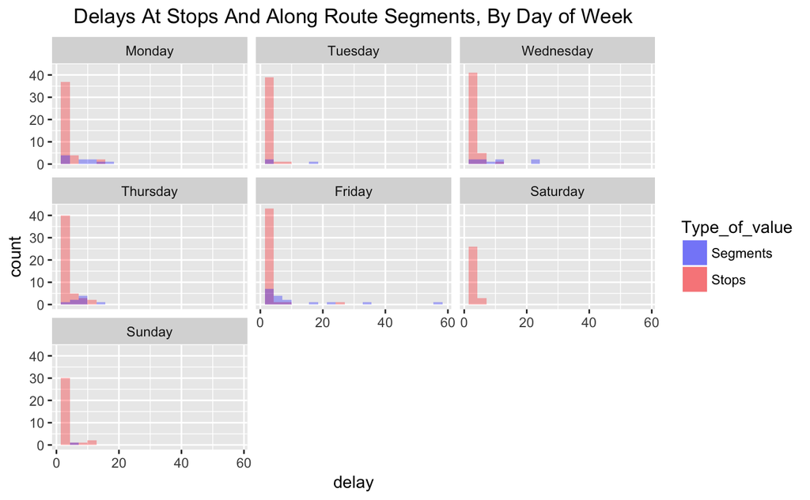

```r
ggplot(data=delays_by_type, aes(x=delay)) +
  geom_histogram(data=subset(delays_by_type,Type_of_value=="stop"),aes(fill=Type_of_value),alpha=0.3,bins=20) +
  geom_histogram(data=subset(delays_by_type,Type_of_value=="seg"),aes(fill=Type_of_value),alpha=0.3,bins=20) +
  scale_fill_manual(name="Type_of_value", values = c("blue","red"),labels = c("Segments","Stops")) +
  facet_wrap(~day.of.week, nrow = 3) +
  ggtitle("Delays At Stops And Along Route Segments, By Day of Week") +
  theme(plot.title = element_text(hjust = 0.5))
```

```r
NA
NA
NA
```

```r
haltstellen1 <- read_csv("../data/other_data/HALTESTELLEN_2014.csv")
```

### The following lines extract all the stations that were in use in the first 52 weekly delay data sets. Then, a bunch of datasets are constructed to hold the delay data for each line, organized by magnitude of delay. These dataset are then filled in code in adjusted_stop_delays.Rmd

```r
stations <- station.data %>%
  group_by(halt_kurz) %>%
  summarize(lat = mean(GPS_Latitude,na.rm=TRUE), lon = mean(GPS_Longitude,na.rm=TRUE))
```

### Which and how many halt_kurz names are in the 2014 .csv file but not in the 2015 - 2017 .csv files?

```r
haltstellen2 <- haltstellen1 %>%
  filter(!(haltstellen1$Haltestellenkurzname %in% unique(stations$halt_kurz))) %>%
  rename(halt_kurz = Haltestellenkurzname)
(dim(haltstellen2))
```

```
[1] 58  4
```

```r
head(haltstellen2)
```

| Haltestellen_Id | Haltestellennummer | halt_kurz | Haltestellenlangname |
| --- | --- | --- | --- |
| 677 | 459 | BDOL | Z\xcc_rich |
| 606 | 445 | BENG | Benglen |
| 685 | 2090 | BERG | Z\xcc_rich |
| 523 | 501 | BIRMBHF | Birmensdorf ZH |
| 739 | 2570 | BIRMSTE | Birmensdorf ZH |
| 702 | 3787 | BUHO | Z\xcc_rich |

#### How many stations are in the delay data sets?

```r
length(unique(station.data$halt_kurz))
```

```
[1] 715
```

#### How many stations are in the delay datasets and in the 2014 list of stations?

```r
sum(unique(station.data$halt_kurz) %in% haltstellen1$Haltestellenkurzname)
```

```
[1] 694
```

#### Are all the stations in the 2014 station list also in the delay datasets?

```r
sum(haltstellen1$Haltestellenkurzname %in% unique(station.data$halt_kurz))
```

```
[1] 694
```

```r
#haltstellen.latlon <- left_join(haltstellen1,stations, by = c("halt_kurz" = "halt_kurz"))
haltstellen.latlon <- stations
```

#### A function to extract the names of the stations and expand a vector with new names

#### NOT RUN

```r
make_haltstelle_list <- function(test.week.name,names_vec){
  test.week <- read_csv(test.week.name)
  haltstelle <- test.week %>%
                group_by(halt_kurz_von1) %>%
                summarize()
  names_vec <- c(names_vec,haltstelle$halt_kurz_von1[!(haltstelle$halt_kurz_von1 %in% names_vec)])
  return(names_vec)
}
```

```r
names_vec <- character()
```

#### Go through all the delay data sets and extract all the observed station names

#### NOT RUN

```r
#names_vec <- character()
#temp=list.files('../data/fahrzeiten_data')
#for (i in temp){
#  names_vec <- make_haltstelle_list(paste("../data/fahrzeiten_data/",i,sep=''),names_vec)
#}
```

#### Make a tibble with the names of the stations in the delays data sets

#### NOT RUN

```r
#station.names <- tibble(stations=names_vec)
```

#### write the extracted station names and their lat lons

```r
# station.names.lat.lon <- inner_join(station.names,stations,by = c("stations" = "halt_kurz"))
# write_csv(station.names.lat.lon,"../data/other_data/station_names_lat_lon.csv")
write_csv(haltstellen.latlon,"../data/other_data/station_names_lat_lon.csv")
```

#### Extract the line numbers of all lines in several 2015-2016 delay data sets

```r
make_line_list <- function(test.week.name,names_vec){
  test.week <- as_tibble(read.csv(test.week.name))
  values <- test.week %>%
                #mutate(linie.char = as.character(linie)) %>%
                group_by(linie) %>%
                summarize()
  names_vec <- c(names_vec,values$linie[!(values$linie %in% names_vec)])
  return(names_vec)
}
```

```r
unique.lines <- numeric()
temp=list.files('../data/fahrzeiten_data')
data2extract <- c(1,20,30)
for (i in data2extract) {
  dname<- paste('../data/fahrzeiten_data/',temp[i],sep = "")
  unique.lines <- make_line_list(dname,unique.lines)
}
unique.lines.c <- as.character(unique.lines)
unique.lines.tib <- tibble(nums = seq(1,length(unique.lines.c)),
                       lines = unique.lines.c)
write_csv(unique.lines.tib,"../data/other_data/unique_lines.csv")
```

```r
w1 <- paste('../data/fahrzeiten_data/',temp[1],sep = "")
w20 <- paste('../data/fahrzeiten_data/',temp[20],sep = "")
w30 <- paste('../data/fahrzeiten_data/',temp[30],sep = "")
week1 <- as_tibble(read.csv(w1,stringsAsFactors = FALSE))
week20 <- as_tibble(read.csv(w20,stringsAsFactors = FALSE))
week30 <- as_tibble(read.csv(w30,stringsAsFactors = FALSE))
test.week <- bind_rows(week1,week20,week30)
```

```r
lines.stops <- vector("list",length(unique.lines))
names(lines.stops) <- as.character(unique.lines)
for (i in unique.lines){
  eval(parse(text=paste("stops <-  unique(test.week$halt_kurz_von1[which((test.week$linie==",i,")==TRUE)])",sep='')))
  lines.stops[[which(names(lines.stops)==as.character(i))]] <- list(stops=stops)
}
```

```r
for (i in unique.lines) {
  stops.1 <- as.character(eval(parse(text=paste("lines.stops[['",i,"']]",sep='')))$stops)
  print(paste("the numer of stops for line ",i," is ",length(stops.1),sep=''))
  data.one <- tibble(stops = stops.1,
                     line = rep(as.character(i),length(stops.1)),
                     del_1_1 = rep(0,length(stops.1)),
                     del_1_2 = rep(0,length(stops.1)),
                     del_2_1 = rep(0,length(stops.1)),
                     del_2_2 = rep(0,length(stops.1)),
                     del_3_1 = rep(0,length(stops.1)),
                     del_3_2 = rep(0,length(stops.1)),
                     del_4_1 = rep(0,length(stops.1)),
                     del_4_2 = rep(0,length(stops.1)),
                     del_5_1 = rep(0,length(stops.1)),
                     del_5_2 = rep(0,length(stops.1)),
                     del_6_1 = rep(0,length(stops.1)),
                     del_6_2 = rep(0,length(stops.1))
                     )

  fname <- paste("../data/stop_delays/stops_delays_52_weeks_line_",i,".csv",sep='')
  write_csv(data.one,fname)
}
```

[output not shown]

### Create a second set of tables for further development

```r
for (i in unique.lines) {
  stops.1 <- as.character(eval(parse(text=paste("lines.stops[['",i,"']]",sep='')))$stops)
  print(paste("the numer of stops for line ",i," is ",length(stops.1),sep=''))
  data.one <- tibble(stops = stops.1,
                     line = rep(as.character(i),length(stops.1)),
                     del_1_1 = rep(0,length(stops.1)),
                     del_1_2 = rep(0,length(stops.1)),
                     del_2_1 = rep(0,length(stops.1)),
                     del_2_2 = rep(0,length(stops.1)),
                     del_3_1 = rep(0,length(stops.1)),
                     del_3_2 = rep(0,length(stops.1)),
                     del_4_1 = rep(0,length(stops.1)),
                     del_4_2 = rep(0,length(stops.1)),
                     del_5_1 = rep(0,length(stops.1)),
                     del_5_2 = rep(0,length(stops.1)),
                     del_6_1 = rep(0,length(stops.1)),
                     del_6_2 = rep(0,length(stops.1))
                     )
  fname <- paste("../data/stop_delays2/stops_delays_52_weeks_line_",i,".csv",sep='')
  write_csv(data.one,fname)
}
```

```
[1] "the numer of stops for line 2 is 44"
[1] "the numer of stops for line 3 is 45"
[1] "the numer of stops for line 4 is 36"
[1] "the numer of stops for line 5 is 36"
[1] "the numer of stops for line 6 is 35"
[1] "the numer of stops for line 7 is 37"
[1] "the numer of stops for line 8 is 32"
[1] "the numer of stops for line 9 is 43"
[1] "the numer of stops for line 10 is 31"
[1] "the numer of stops for line 11 is 48"
[1] "the numer of stops for line 12 is 23"
[1] "the numer of stops for line 13 is 51"
[1] "the numer of stops for line 14 is 38"
[1] "the numer of stops for line 15 is 32"
[1] "the numer of stops for line 17 is 58"
```

[output cut: 63 more lines]